# Matthew Bierman, Homework 1

## 1.

This dataset has 506 rows/observations and 14 columns/variables and is for housing values in Boston suburbs. The columns contain data such as crime rate, proportion of residential land zoned for lots, average number of rooms per dwelling, and pupial-teacher ratio.

```r
library(MASS)   # Loading library MASS
data(Boston)    # Load Boston dataset into memory
str(Boston)     # Overview of data
```

```
## 'data.frame':    506 obs. of  14 variables:
##  $ crim   : num  0.00632 0.02731 0.02729 0.03237 0.06905 ...
##  $ zn     : num  18 0 0 0 0 0 12.5 12.5 12.5 12.5 ...
##  $ indus  : num  2.31 7.07 7.07 2.18 2.18 2.18 7.87 7.87 7.87 7.87 ...
##  $ chas   : int  0 0 0 0 0 0 0 0 0 0 ...
##  $ nox    : num  0.538 0.469 0.469 0.458 0.458 0.458 0.524 0.524 0.524 0.524 ...
##  $ rm     : num  6.58 6.42 7.18 7 7.15 ...
##  $ age    : num  65.2 78.9 61.1 45.8 54.2 58.7 66.6 96.1 100 85.9 ...
##  $ dis    : num  4.09 4.97 4.97 6.06 6.06 ...
##  $ rad    : int  1 2 2 3 3 3 5 5 5 5 ...
##  $ tax    : num  296 242 242 222 222 222 311 311 311 311 ...
##  $ ptratio: num  15.3 17.8 17.8 18.7 18.7 18.7 15.2 15.2 15.2 15.2 ...
##  $ black  : num  397 397 393 395 397 ...
##  $ lstat  : num  4.98 9.14 4.03 2.94 5.33 ...
##  $ medv   : num  24 21.6 34.7 33.4 36.2 28.7 22.9 27.1 16.5 18.9 ...
```

## 2.

```r
head(Boston, n = 3)       # Displaying the first few rows
```

```
##      crim zn indus chas   nox    rm  age    dis rad tax ptratio  black
## 1 0.00632 18  2.31    0 0.538 6.575 65.2 4.0900   1 296    15.3 396.90
## 2 0.02731  0  7.07    0 0.469 6.421 78.9 4.9671   2 242    17.8 396.90
## 3 0.02729  0  7.07    0 0.469 7.185 61.1 4.9671   2 242    17.8 392.83
##   lstat medv
## 1  4.98 24.0
## 2  9.14 21.6
## 3  4.03 34.7
```

```r
tail(Boston, n = 2)       # Displaying the last 2 rows
```

```
##        crim zn indus chas   nox    rm  age    dis rad tax ptratio  black
## 505 0.10959  0 11.93    0 0.573 6.794 89.3 2.3889   1 273      21 393.45
## 506 0.04741  0 11.93    0 0.573 6.030 80.8 2.5050   1 273      21 396.90
##     lstat medv
## 505  6.48 22.0
## 506  7.88 11.9
```

```r
Boston[5,]                # Displaying row 5
```

```
##      crim zn indus chas   nox    rm  age    dis rad tax ptratio black
## 5 0.06905  0  2.18    0 0.458 7.147 54.2 6.0622   3 222    18.7 396.9
##   lstat medv
## 5  5.33 36.2
```

```r
head(Boston[,1], n = 3)   # Displaying the first few rows of column 1
```

```
## [1] 0.00632 0.02731 0.02729
```

```r
names(Boston)             # Displaying the variable names
```

```
##  [1] "crim"    "zn"      "indus"   "chas"    "nox"     "rm"      "age"
##  [8] "dis"     "rad"     "tax"     "ptratio" "black"   "lstat"   "medv"
```

## 3.

```r
cat("Mean of Crime Rate:", mean(Boston$crim))
```

```
## Mean of Crime Rate: 3.613524
```

```r
cat("Median of Crime Rate:", median(Boston$crim))
```

```
## Median of Crime Rate: 0.25651
```

```r
cat("Range of Crime Rate:", range(Boston$crim)[2] - range(Boston$crim)[1]) # range() returns a vector <min, max>, so taking max - min will result in the range of the values
```

```
## Range of Crime Rate: 88.96988
```

## 4.

This histogram tells us that a majority of towns in Boston have a very low crime rate, or none at all.

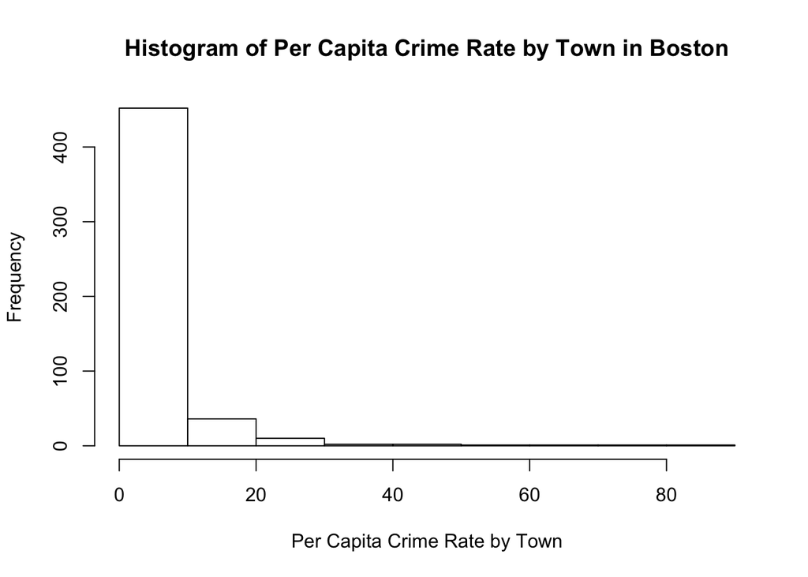

```r
hist(Boston$crim, main = paste("Histogram of Per Capita Crime Rate by Town in Boston"), xlab = paste("Per Capita Crime Rate by Town"))
```

## 5.

A correlation value of -0.38 between crime rate and median house value means there is a loose, negative correlation between crime rate and median house value. The crime rate column is not that useful in predicting median house value.

```r
cat("Correlation between crime rate and median house value:", cor(Boston$crim, Boston$medv))
```

```
## Correlation between crime rate and median house value: -0.3883046
```

## 6.

There is a slightly strong, positive correlation between the number of rooms in a house and its value/price, meaning as the number of rooms increases, the value of the house will also generally increase.

```r
cat("Correlation between number of rooms and median house value:", cor(Boston[,6], Boston[,14]))
```

```
## Correlation between number of rooms and median house value: 0.6953599
```

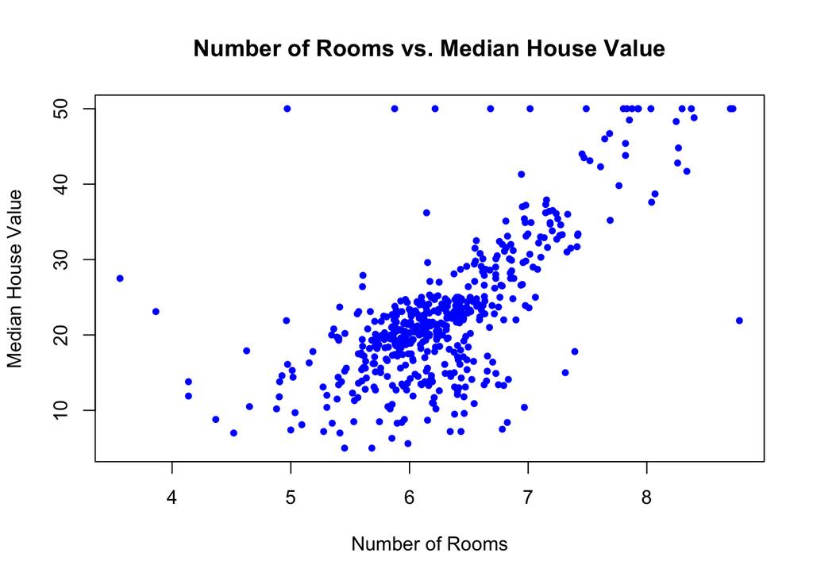

```r
plot(Boston$rm, Boston$medv, main = "Number of Rooms vs. Median House Value", xlab = paste("Number of Rooms"), ylab = paste("Median House Value"), pch = 20, col = "blue")
```

## 7.

Converting the chas column from numerical to categorical values causes the graphs to view the data differently in that chas as numerical values are just (x, y) coordinates, but chas as categorical values is category 0 or category 1. Category 0 means the house does not bound the Charles River and category 1 means the house bounds the Charles River. This means the graph is plotting the values of houses that bound the river and the plotting the values of houses that don’t bound the river separately.

```r
is.factor(Boston$chas)                # Checking if chas column is a factor variable
```

```
## [1] FALSE
```

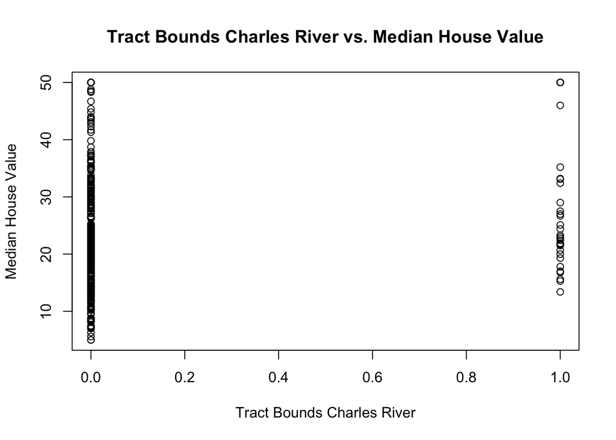

```r
plot(Boston$chas, Boston$medv, main = "Tract Bounds Charles River vs. Median House Value", xlab = "Tract Bounds Charles River", ylab = "Median House Value")
```

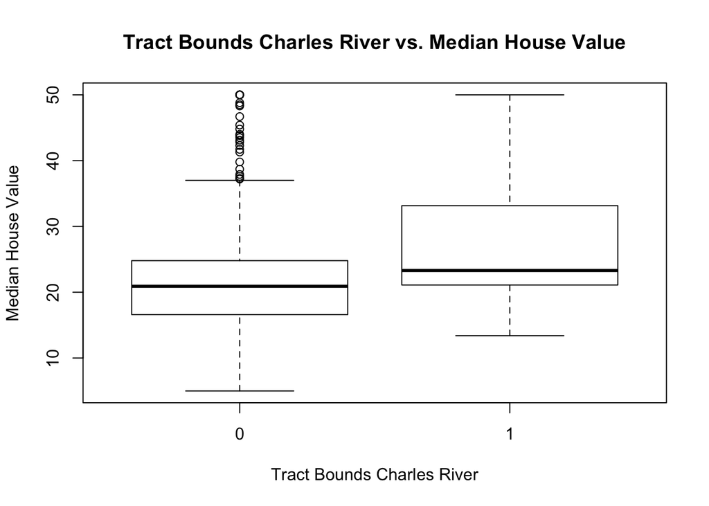

```r
Boston$chas <- factor(Boston$chas)    # Converting chas column to factors
plot(Boston$chas, Boston$medv, main = "Tract Bounds Charles River vs. Median House Value", xlab = "Tract Bounds Charles River", ylab = "Median House Value")
```

## 8.

```r
summary(Boston$rad)
```

```
##    Min. 1st Qu.  Median    Mean 3rd Qu.    Max.
##   1.000   4.000   5.000   9.549  24.000  24.000
```

```r
unique(Boston$rad)
```

```
## [1]  1  2  3  5  4  8  6  7 24
```

```r
sum(Boston$rad == 24)
```

```
## [1] 132
```

```r
cat (100 * nrow(Boston[Boston$rad == 24,]) / dim(Boston)[1], "%", sep = "")
```

```
## 26.08696%
```

## 9.

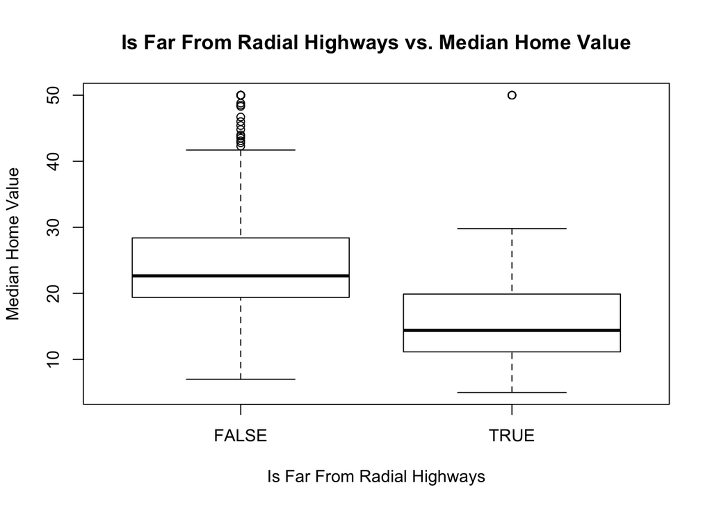

```r
Boston$far <- ifelse(Boston$rad == 24, Boston$far <- TRUE, Boston$far <- FALSE)
Boston$far <- factor(Boston$far)
plot(Boston$far, Boston$medv, main = "Is Far From Radial Highways vs. Median Home Value", xlab = "Is Far From Radial Highways", ylab = "Median Home Value")
```

## 10.

The neighborhood with the highest median home value, index 162, has a higher crime rate than 50% of other neighborhoods in Boston, has more rooms than over 75% of other neighboorhoods in Boston, has the lowest percentage of lower status of the population compared to other neighborhoods in Boston, and over 75% of other neighborhoods in Boston have a median home value that is less than or equal to half of the highest median home value.

```r
summary(Boston[, c("crim", "rm", "lstat", "medv")])
```

```
##       crim                rm            lstat            medv
##  Min.   : 0.00632   Min.   :3.561   Min.   : 1.73   Min.   : 5.00
##  1st Qu.: 0.08204   1st Qu.:5.886   1st Qu.: 6.95   1st Qu.:17.02
##  Median : 0.25651   Median :6.208   Median :11.36   Median :21.20
##  Mean   : 3.61352   Mean   :6.285   Mean   :12.65   Mean   :22.53
##  3rd Qu.: 3.67708   3rd Qu.:6.623   3rd Qu.:16.95   3rd Qu.:25.00
##  Max.   :88.97620   Max.   :8.780   Max.   :37.97   Max.   :50.00
```

```r
Boston[which.max(Boston$medv), c("crim", "rm", "lstat", "medv")]
```

```
##        crim    rm lstat medv
## 162 1.46336 7.489  1.73   50
```